# Exposure analysis to simulation - example

# Illustrative non-cat exposure analysis to loss simulation example

Using a simplified, one line of business example, this notebook will:

- Perform an exposure analysis to estimate expected losses to excess of loss reinsurance layers
- Squish parametric ground up loss distributions by policy limit into a single piecewise linear distribution
- **TODO**: adjust piecewise linear distribution for custom view of large losses
- Simulate attritional and large losses using the collective risk model with frequency contagion parameter

```r
knitr::opts_chunk$set(
    echo = TRUE,
    message = FALSE,
    warning = FALSE
)
```

```r
library(knitr)
library(tibble)
library(dplyr)
library(tidyr)
library(ggplot2)
library(actuar)
library(purrr)
```

# Input

Limit profile for a single line of business with $100m of premium and a 65% gross loss ratio. We also assume that each policy limit band has a lognormal underlying ground up severity distribution with $mu = 10$ and $sigma = 2$.

```r
limit_profile <- tribble(
  ~id, ~limit, ~attach, ~premium, ~gross_loss_ratio, ~lognormal_mu, ~lognormal_sigma,
    1, 500000,       0,      3e7,              0.65,            10,                2,
    2,    1e6,       0,    2.5e7,              0.65,            10,                2,
    3,  2.5e6,       0,      2e7,              0.65,            10,                2,
    4,    5e6,       0,    1.5e7,              0.65,            10,                2,
    5,   10e6,       0,    1.0e7,              0.65,            10,                2,
)
kable(limit_profile)
```

| id | limit | attach | premium | gross_loss_ratio | lognormal_mu | lognormal_sigma |
| --- | --- | --- | --- | --- | --- | --- |
| 1 | 5.0e+05 | 0 | 3.0e+07 | 0.65 | 10 | 2 |
| 2 | 1.0e+06 | 0 | 2.5e+07 | 0.65 | 10 | 2 |
| 3 | 2.5e+06 | 0 | 2.0e+07 | 0.65 | 10 | 2 |
| 4 | 5.0e+06 | 0 | 1.5e+07 | 0.65 | 10 | 2 |
| 5 | 1.0e+07 | 0 | 1.0e+07 | 0.65 | 10 | 2 |

# Exposure analysis for XOL reinsurance layers

Given the ground up loss and limit profile assumptions, we can calculate the portion of the gross losses that exposure excess of loss reinsurance layers of $4m xs $1m and $5m xs $5m.

The graph below shows that three of our policy limit bands expose the reinsurance layers, with bands 3 and 4 exposing the first layer only, and band 5 fully exposing both layers.

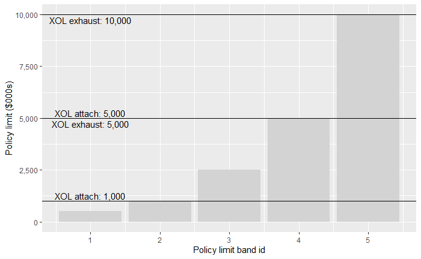

```r
layers <- tribble(
  ~layer_id, ~layer_limit, ~layer_attach, ~layer_exhaust,
          1,          4e6,           1e6,            5e6,
          2,          5e6,           5e6,           10e6,
)

limit_profile %>%
  ggplot(aes(y = limit / 1000, x = id)) +
  geom_col(fill = "light gray") +
  geom_hline(yintercept = layers$layer_attach/1000) +
  geom_hline(yintercept = layers$layer_exhaust/1000) +
  geom_text(aes(x = c(1,1), y = layers$layer_attach/1000+250,
                label = paste0("XOL attach: ", scales::comma(layers$layer_attach/1000))), data = layers) +
  geom_text(aes(x = c(1), y = layers$layer_exhaust/1000-250,
                label = paste0("XOL exhaust: ", scales::comma(layers$layer_exhaust/1000))), data = layers) +
  scale_y_continuous(labels = scales::comma_format()) +
  ylab("Policy limit ($000s)") + xlab("Policy limit band id")
```

To calculate the portion of loss that falls in the reinsurance layers, we use the limited expected value (LEV) function.

$pctlossinlayer = (LEV[min(policy limit + policy attach, reinsurance exhaust)] - LEV[reinsurance attach]) / (LEV[policy limit + policy attach] - LEV[policy attach])$

Expected frequency drops out of the equation as it is in both the numerator and denominator, so we can just work with the limited severities.

```r
# add gross loss, average severity, mean frequency by limit band
limit_profile <- limit_profile %>%
  mutate(limit_plus_attach = limit + attach) %>%
  mutate(gross_loss = premium * gross_loss_ratio,
         avg_sev = levlnorm(limit, lognormal_mu, lognormal_sigma),
         mean_freq = gross_loss / avg_sev)

# calculate percent of loss in layer
limit_profile_exposure <- limit_profile %>%
  crossing(layers) %>%
  mutate(lev_top = levlnorm(pmin(limit_plus_attach, layer_exhaust), lognormal_mu, lognormal_sigma) -
                   levlnorm(pmin(limit_plus_attach, layer_attach), lognormal_mu, lognormal_sigma),
         lev_bottom = levlnorm(limit_plus_attach, lognormal_mu, lognormal_sigma) -
                      levlnorm(attach, lognormal_mu, lognormal_sigma),
         pct_in_layer = lev_top / lev_bottom,
         loss_in_layer = pct_in_layer * premium * gross_loss_ratio)

# summarize exposure results
exposure_summary <- limit_profile_exposure %>%
  select(id, limit, attach, premium, gross_loss_ratio, layer_id, pct_in_layer) %>%
  spread(layer_id, pct_in_layer) %>%
  rename("layer_1_pct_in_layer" = `1`, "layer_2_pct_in_layer" = `2`)

exposure_summary <- exposure_summary %>%
  left_join(limit_profile_exposure %>%
    select(id, layer_id, loss_in_layer) %>%
    spread(layer_id, loss_in_layer) %>%
    rename("layer_1_layer_loss" = `1`, "layer_2_layer_loss" = `2`),
  by = "id")

exposure_total <- exposure_summary %>% summarise_all(sum)
exposure_total[1, c(1,2,3,5,6,7)] <- NA
exposure_total[1, 5] <- 0.65
exposure_total[1, 6:7] <- exposure_total[1, 8:9] / (exposure_total$premium[1] * exposure_total$gross_loss_ratio[1])

exposure_summary <- exposure_summary %>%
  bind_rows(exposure_total)

exposure_summary
```

| id | limit | attach | premium | gross_loss_ratio | layer_1_pct_in_layer | layer_2_pct_in_layer | layer_1_layer_loss | layer_2_layer_loss |
| --- | --- | --- | --- | --- | --- | --- | --- | --- |
| 1 | 5.0e+05 | 0 | 3.0e+07 | 0.65 | 0.0000000 | 0.000000000 | 0 | 0.0 |
| 2 | 1.0e+06 | 0 | 2.5e+07 | 0.65 | 0.0000000 | 0.000000000 | 0 | 0.0 |
| 3 | 2.5e+06 | 0 | 2.0e+07 | 0.65 | 0.1848217 | 0.000000000 | 2402682 | 0.0 |
| 4 | 5.0e+06 | 0 | 1.5e+07 | 0.65 | 0.2636307 | 0.000000000 | 2570399 | 0.0 |
| 5 | 1.0e+07 | 0 | 1.0e+07 | 0.65 | 0.2468072 | 0.063814586 | 1604247 | 414794.8 |
| NA | NA | NA | 1.0e+08 | 0.65 | 0.1011897 | 0.006381459 | 6577328 | 414794.8 |

The total expected loss into the first layer is $6,577,328 and for layer 2 $414,795.

The calculations get slightly more complicated when you add non-zero attachment points and when you have stacking of policies limits (e.g. umbrella, shared and layered business).

# Squish distributions into a single distribution

Next we convert our 5 lognormal distributions into a single piecewise linear distribution. This is done in part for convenience and speed (working with a single distribution), but it also allows us to refelct the point masses at each limit profile band and will make it easier to adjust our curves based on the experience analysis.

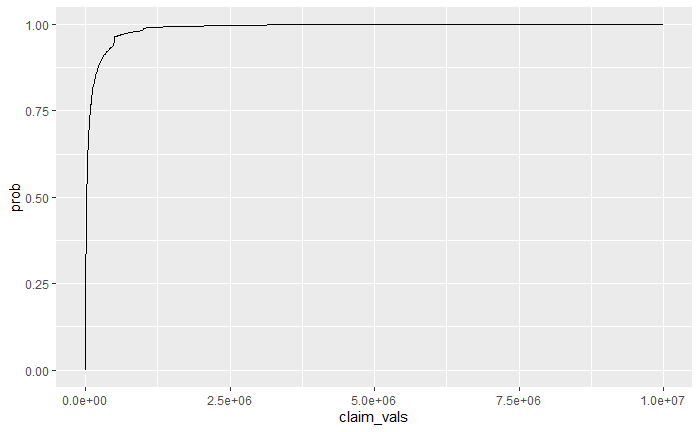

```r
# calculate point masses at each policy limit
point_masses <- limit_profile %>%
  mutate(pt_mass = (1 - plnorm(limit, lognormal_mu, lognormal_sigma)) * mean_freq) %>%
  select(id, limit, mean_freq, pt_mass)

# function to create list of claim amounts for PL
create_claim_sizes <- function(max_claim_size, init_step_size = 100, max_steps = 100){

  step_size <- init_step_size
  claim_size_list <- vector(mode = "numeric")
  claim_size <- 0
  len_list <- 1

  while (claim_size < max_claim_size){
    for(i in 1:max_steps){
      claim_size <- (i-1) * step_size
      if(claim_size <= max_claim_size){
        claim_size_list[len_list] <- claim_size
        len_list <- len_list + 1
      }
    }
    step_size <- 10 * step_size
  }

  claim_size_list
}

# run function and explicitly add values at policy limits
claim_sizes <- create_claim_sizes(10e6)

# being lazy and just adding 0.001 to policy limit, ideally would be exact same dollar amount
claim_sizes <- sort(unique(c(claim_sizes, point_masses$limit+0.001)))

# calculate 1 - CDF(claim_sizes) excluding point masses for each policy limit band and then sum
# weighting by frequencies
pl_dist <- limit_profile %>%
  mutate(claim_vals = list(claim_sizes)) %>%
  unnest(claim_vals) %>%
  mutate(surv_prob = if_else(claim_vals < limit,
                             ((1 - plnorm(claim_vals, lognormal_mu, lognormal_sigma)) / (1 - 0)) * mean_freq,
                             0)) %>%
  group_by(claim_vals) %>%
  summarise(prob = sum(surv_prob))

# convert from frequencies to probabilities
total_freq <- sum(limit_profile$mean_freq)
pl_dist$prob <- 1 - pl_dist$prob / total_freq

# now add point masses
pl_dist <- pl_dist %>%
  left_join(point_masses %>% select(limit, pt_mass), by = c("claim_vals" = "limit")) %>%
  mutate(prob = if_else(!is.na(pt_mass), pmax(lag(prob), prob - pt_mass / total_freq / 2), prob),
         prob = if_else(!is.na(lag(pt_mass)), pmin(1, lag(prob) + lag(pt_mass) / total_freq / 2), prob)) %>%
  select(-pt_mass)

pl_dist %>%
  ggplot(aes(y = prob, x = claim_vals)) +
  geom_line() +
  xlim(0, 10e6)
```

Now we have a single piecewise linear distribution that reflects our ground up severity distributions and policy limit profiles.

# Adjust PL distribution to match targets

**TO DO**: add logic for adjusting the PL distribution to match target expected loss by layer

# Simulate losses using collective risk model with frequency contagion parameter

See papers folder for references on this methodology. We’ll use the Homer and Rosengarten methodology for this example.

We’ll split the losses into attritional and large using a loss threshold of $500k.

We’ll assume our mixing variable is gamma distribution with a mean of 1 and CV of 30% and that the attritional losses are lognormally distributed.

```r
attr_thres <- 500000
n_trials <- 10000
mix_cv <- 0.3

set.seed(22)

# simulate frequency mixing variable
mixing_var <- rgamma(n_trials, shape = 1 / (mix_cv)^2, scale = mix_cv^2)

# simulate total number of claims given overall mean and simulated mixing variable
num_claims_total <- rpois(n_trials, total_freq * mixing_var)

# lookup the probability of a claim > 500k (hack - not interpolating and hardcoding that
#  we want second instance of policy limit claim value
prob_large_claim <- 1 - pl_dist[which(pl_dist$claim_vals==(attr_thres+0.001))+1,2]$prob

num_claims_large <- rbinom(n_trials, num_claims_total, prob_large_claim)
num_claims_small <- num_claims_total - num_claims_large

# calculate conditional large claim severity distribution
pl_dist_large <- pl_dist %>%
  filter(claim_vals >= (attr_thres+0.001)) %>%
  mutate(prob = pmax(0, (prob - (1 - prob_large_claim)) / prob_large_claim)) %>%
  mutate(incr = prob - lag(prob, default = 0))

# simulate large claims
# this doesn't interpolate between claim sizes, so that introduces some sampling error
large_losses <- tibble(num_claims = num_claims_large, trial = 1:n_trials) %>%
  mutate(loss = map(num_claims, ~ sample(pl_dist_large$claim_vals, .x,
                                         replace = TRUE, prob = pl_dist_large$incr))) %>%
  unnest() %>%
  group_by(trial) %>%
  mutate(sequence = 1:n()) %>%
  ungroup()

# hardcode attritional severity mean and cv for now b/c I'm too lazy to write code to do it
attr_sev_mean <- 67946
attr_sev_cv <- 1.6451
attr_mean <- attr_sev_mean * num_claims_small
attr_cv <- sqrt((1 + attr_sev_cv^2) / num_claims_small)
attr_sigma <- sqrt(log(1 + attr_cv ^ 2))
attr_mu <- log(attr_mean) - attr_sigma^2/2

# simulate attritional losses
attr_losses <- rlnorm(n_trials, attr_mu, attr_sigma)
```

We can layer the simulated large losses and compare the layer stats to what we calculated in the exposure analysis section.

```r
large_losses_wlayers <- large_losses %>%
  mutate(layer_1 = pmin(layers$layer_limit[1], pmax(loss - layers$layer_attach[1], 0))) %>%
  mutate(layer_2 = pmin(layers$layer_limit[2], pmax(loss - layers$layer_attach[2], 0)))

large_loss_by_trial <- large_losses_wlayers %>%
  group_by(trial, num_claims) %>%
  summarise_all(sum) %>%
  ungroup(trial) %>%
  select(-sequence) %>%
  right_join(tibble(trial = 1:n_trials), by = "trial") %>%
  mutate_all(replace_na, 0)

large_loss_summary <- large_loss_by_trial %>%
  gather(variable, value, -trial) %>%
  select(-trial) %>%
  group_by(variable) %>%
  summarise(mean = mean(value),
            cv = sd(value) / mean(value)) %>%
  mutate(exposure = c(exposure_total$layer_1_layer_loss,
                      exposure_total$layer_2_layer_loss,NA,NA)) %>%
  mutate(error = mean / exposure - 1)
large_loss_summary
```

| variable | mean | cv | exposure | error |
| --- | --- | --- | --- | --- |
| layer_1 | 6.888610e+06 | 0.6310885 | 6577327.9 | 0.04732653 |
| layer_2 | 4.213300e+05 | 3.1113859 | 414794.8 | 0.01575524 |
| loss | 2.571231e+07 | 0.4076128 | NA | NA |
| num_claims | 2.163350e+01 | 0.3694401 | NA | NA |

The `error` is less than 5% for both layers. This can be improvement by smarter simulation methods.

Summary of attritional, large, total aggregate losses:

```r
total_losses <- large_loss_by_trial %>%
  mutate(loss_attr = attr_losses,
         loss_total = loss + loss_attr)

loss_summary <- total_losses %>%
  select(trial, loss, loss_attr, loss_total) %>%
  gather(variable, value, -trial) %>%
  select(-trial) %>%
  group_by(variable) %>%
  summarise(mean = mean(value),
            cv = sd(value) / mean(value))
loss_summary
```

| variable | mean | cv |
| --- | --- | --- |
| loss | 25712308 | 0.4076128 |
| loss_attr | 39889650 | 0.3127836 |
| loss_total | 65601958 | 0.3238465 |

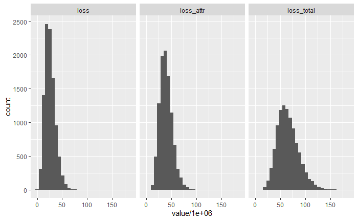

```r
total_losses %>%
  select(trial, loss, loss_attr, loss_total) %>%
  gather(variable, value, -trial) %>%
  ggplot(aes(x = value/1e6)) +
  geom_histogram() +
  facet_wrap(~ variable) +
  scale_x_continuous(labels = scales::comma_format())
```